# Branch Opening Results

# 4 Baseline Opening Model

## 4.1 Define Control Variables

Set up control variable specifications for opening regressions:

```r
# State-level controls with extensive covariates
setFixest_fml(
  ..ctrl_state_opening = ~ log_zip_deposits + lag_county_deposit_gr +
                          lag_hmda_mtg_amt_gr + lag_cra_loan_amount_amt_lt_1m_gr +
                          lag_establishment_gr + lag_payroll_gr + lmi +
                          log1p(lag_county_cra_volume)+log1p(lag_county_mortgage_volume)|
                          state_yr + bank_yr,

  # County-level controls (more parsimonious with county-year FE)
  ..ctrl_county_opening = ~ log_zip_deposits | county_yr + bank_yr
)

# Create coefficient labels dictionary
covariate_labels_dict <- c(
  "deposit_beta" = "Deposit Beta",
  "log_zip_deposits" = "log(Zip Deposits)",
  "lag_county_deposit_gr" = "County Deposit Growth",
  "lag_hmda_mtg_amt_gr" = "Mortgage Growth",
  "lag_cra_loan_amount_amt_lt_1m_gr" = "CRA Loan Growth",
  "log(lag_county_mortgage_vol)" = "log(County Mortgage Volume)",
  "log(lag_county_cra_vol)" = "log(County CRA Volume)",
  "lag_establishment_gr" = "Establishment Growth",
  "lag_payroll_gr" = "Payroll Growth",
  "lmi" = "Low-to-Moderate Income",
  "log1p(lag_county_cra_volume)" = "log(Lag County CRA Volume)",
  "log1p(lag_county_mortgage_volume)" = "log(Lag County Mortgage Volume)",
  # Reduced form
  "college_frac" = "College frac",
  "log(family_income)" = "Income",
  "dividend_frac" = "Stock market frac",
  "factor_age_bin2" = "Age Q1-Q2",
  "factor_age_bin3" = "Age Q2-Q3",
  "factor_age_bin4" = "Age >Q3",
  "lag_county_deposit_hhi" = "County deposit HHI",
  "population_density" = "Population density",
  "sophisticated" = "Sophisticated zipcode",
  # Usage (for pandemic-era regressions)
  "change_visits" = "Drop in visits",
  "log(distance_km)" = "Log(Distance km)"
)
omit_controls <- as.vector(covariate_labels_dict)
omit_controls <- sub("^log\\(", "", omit_controls)
omit_controls <- sub("\\)$", "", omit_controls)


# Year ranges by economic regime (same as closure analysis)
yr_range <- list(2001:2007, 2008:2011, 2012:2019, 2020:2025)
```

# 5 Univariate: Openings by Deposit Beta Decile

Average opening rate (share of zip codes with a new branch) by deposit beta decile and rate cycle. Deciles are computed within bank-year (within bank) or within year (not within bank).

## 5.1 Within bank (decile within bank-year)

```
            used   (Mb) gc trigger    (Mb)   max used    (Mb)
Ncells   2510677  134.1    4017965   214.6    4017965   214.6
Vcells 508407532 3878.9 1439768604 10984.6 1438272148 10973.2
```

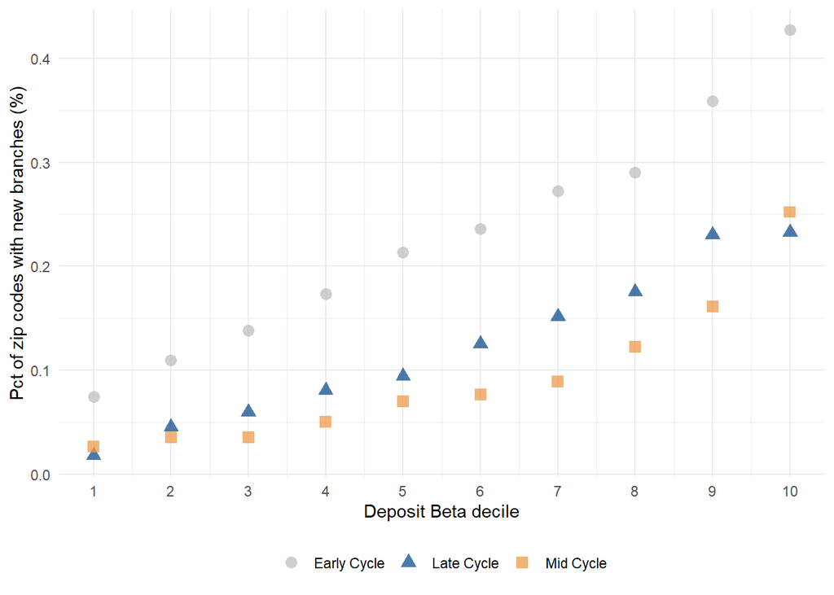

Figure 1: Pct of zip codes with new branches by deposit beta decile (within bank), by cycle

```r
# Deciles: within bank-year and within year
opening_sample[, beta_decile_within_bank := dplyr::ntile(deposit_beta, 10), by = .(RSSDID, yr)]
opening_sample[, beta_decile_within_year := dplyr::ntile(deposit_beta, 10), by = yr]

temp <- opening_sample[!is.na(beta_decile_within_bank), .(openings = mean(new_branch_zip, na.rm = TRUE)), by = .(beta_decile_within_bank, yr)]
temp[, beta_bin := beta_decile_within_bank]

temp1 <- temp[yr %in% 2020:2023, .(openings = mean(openings)), by = beta_bin]
temp1[, cycle := "Late Cycle"]

temp2 <- temp[yr %in% 2015:2019, .(openings = mean(openings, na.rm = TRUE)), by = beta_bin]
temp2[, cycle := "Mid Cycle"]

temp3 <- temp[yr %in% 2001:2014, .(openings = mean(openings, na.rm = TRUE)), by = beta_bin]
temp3[, cycle := "Early Cycle"]

temp_combined <- rbind(temp1, temp2, temp3)
temp_combined[, openings := DescTools::Winsorize(openings, quantile(openings, probs = c(0.05, 0.95), na.rm = TRUE)), by = .(beta_bin, cycle)]

ggplot(temp_combined, aes(x = beta_bin, y = openings * 100, color = cycle)) +
  geom_point(size = 3, alpha = 0.75, aes(shape = cycle)) +
  scale_x_continuous(n.breaks = 10) +
  scale_color_manual(values = c("Late Cycle" = "dodgerblue4", "Mid Cycle" = "tan2", "Early Cycle" = "gray")) +
  theme_minimal() +
  labs(x = "Deposit Beta decile", y = "Pct of zip codes with new branches (%)") +
  theme(legend.position = "bottom", legend.title = element_blank())
rm(temp, temp1, temp2, temp3, temp_combined)
gc(verbose = FALSE)
```

## 5.2 Not within bank (decile within year)

```r
temp <- opening_sample[!is.na(beta_decile_within_year), .(openings = mean(new_branch_zip, na.rm = TRUE)), by = .(beta_decile_within_year, yr)]
temp[, beta_bin := beta_decile_within_year]

temp1 <- temp[yr %in% 2020:2023, .(openings = mean(openings)), by = beta_bin]
temp1[, cycle := "Late Cycle"]

temp2 <- temp[yr %in% 2015:2019, .(openings = mean(openings, na.rm = TRUE)), by = beta_bin]
temp2[, cycle := "Mid Cycle"]

temp3 <- temp[yr %in% 2001:2014, .(openings = mean(openings, na.rm = TRUE)), by = beta_bin]
temp3[, cycle := "Early Cycle"]

temp_combined <- rbind(temp1, temp2, temp3)
temp_combined[, openings := DescTools::Winsorize(openings, quantile(openings, probs = c(0.01, 0.99), na.rm = TRUE)), by = .(beta_bin, cycle)]

ggplot(temp_combined, aes(x = beta_bin, y = openings * 100, color = cycle)) +
  geom_point(size = 3, alpha = 0.75, aes(shape = cycle)) +
  scale_x_continuous(n.breaks = 10) +
  scale_color_manual(values = c("Late Cycle" = "dodgerblue4", "Mid Cycle" = "tan2", "Early Cycle" = "gray")) +
  theme_minimal() +
  labs(x = "Deposit Beta decile", y = "Pct of zip codes with new branches (%)") +
  theme(legend.position = "bottom", legend.title = element_blank())
rm(temp, temp1, temp2, temp3, temp_combined)
gc(verbose = FALSE)
```

```
            used   (Mb) gc trigger    (Mb)   max used    (Mb)
Ncells   2515673  134.4    4017965   214.6    4017965   214.6
Vcells 508424070 3879.0 1439768604 10984.6 1438272148 10973.2
```

```
            used   (Mb) gc trigger    (Mb)   max used    (Mb)
Ncells   2515673  134.4    4017965   214.6    4017965   214.6
Vcells 495347007 3779.2 1439768604 10984.6 1438272148 10973.2
```

[figure not shown]

Figure 2: Pct of zip codes with new branches by deposit beta decile (within year), by cycle

```r
# Drop decile columns from opening_sample; no longer needed for regressions
opening_sample[, c("beta_decile_within_bank", "beta_decile_within_year") := NULL]
gc(verbose = FALSE)
```

## 5.3 Baseline Regressions

Opening regressions examining the relationship between deposit beta and branch openings, controlling for zip-level deposits and other factors:

```r
gc(verbose = FALSE)
```

```
            used   (Mb) gc trigger    (Mb)   max used    (Mb)
Ncells   2506764  133.9    4017965   214.6    4017965   214.6
Vcells 495315417 3779.0 1439768604 10984.6 1438272148 10973.2
```

```r
# Run 6 regressions: all banks, large banks, small banks x state/county controls (one at a time to free memory)
reg_open_baseline <- list()
reg_open_baseline[[1]] <- feols(new_branch_zip ~ deposit_beta + ..ctrl_state_opening, data = opening_sample, vcov = ~RSSDID)
gc(verbose = FALSE)
```

```
            used   (Mb) gc trigger    (Mb)   max used    (Mb)
Ncells   2540232  135.7    4017965   214.6    4017965   214.6
Vcells 678454663 5176.2 1439768604 10984.6 1438272148 10973.2
```

```r
reg_open_baseline[[2]] <- feols(new_branch_zip ~ deposit_beta + ..ctrl_county_opening, data = opening_sample, vcov = ~RSSDID)
gc(verbose = FALSE)
```

```
            used   (Mb) gc trigger    (Mb)   max used    (Mb)
Ncells   2540381  135.7    4017965   214.6    4017965   214.6
Vcells 757014693 5775.6 1439768604 10984.6 1438272148 10973.2
```

```r
large_df <- opening_sample[large_bank == 1]
reg_open_baseline[[3]] <- feols(new_branch_zip ~ deposit_beta + ..ctrl_state_opening, data = large_df, vcov = ~RSSDID)
gc(verbose = FALSE)
```

```
            used   (Mb) gc trigger    (Mb)   max used    (Mb)
Ncells   2540656  135.7    4017965   214.6    4017965   214.6
Vcells 844211560 6440.9 1439768604 10984.6 1438272148 10973.2
```

```r
reg_open_baseline[[4]] <- feols(new_branch_zip ~ deposit_beta + ..ctrl_county_opening, data = large_df, vcov = ~RSSDID)
rm(large_df)
small_df <- opening_sample[large_bank == 0]
gc(verbose = FALSE)
```

```
             used   (Mb) gc trigger    (Mb)   max used    (Mb)
Ncells    2540827  135.7    4017965   214.6    4017965   214.6
Vcells 1226355106 9356.4 1727802324 13182.1 1438272148 10973.2
```

```r
reg_open_baseline[[5]] <- feols(new_branch_zip ~ deposit_beta + ..ctrl_state_opening, data = small_df, vcov = ~RSSDID)
gc(verbose = FALSE)
```

```
             used    (Mb) gc trigger    (Mb)   max used    (Mb)
Ncells    2540986   135.8    4017965   214.6    4017965   214.6
Vcells 1387486403 10585.7 2073442788 15819.2 1709815463 13044.9
```

```r
reg_open_baseline[[6]] <- feols(new_branch_zip ~ deposit_beta + ..ctrl_county_opening, data = small_df, vcov = ~RSSDID)
rm(small_df)
gc(verbose = FALSE)
```

```
             used   (Mb) gc trigger    (Mb)   max used    (Mb)
Ncells    2541093  135.8    4017965   214.6    4017965   214.6
Vcells 1025218634 7821.8 2073442788 15819.2 1709815463 13044.9
```

```r
# Display text table
md_table(etable(reg_open_baseline,
  se.below = TRUE,
  signif.code = c("***" = 0.01, "**" = 0.05, "*" = 0.10),
  headers = list("All Banks" = 2, "Large Banks" = 2, "Small Banks" = 2),
  dict = covariate_labels_dict,
  depvar = FALSE
))
```

```r
rm(reg_open_baseline)
gc(verbose = FALSE)
```

```r
# LaTeX version with AER style (uncomment to use)
# etable(reg_open_baseline,
#   se.below = TRUE,
#   signif.code = c("***" = 0.01, "**" = 0.05, "*" = 0.10),
#   headers = list("All Banks" = 2, "Large Banks" = 2, "Small Banks" = 2),
#   dict = covariate_labels_dict,
#   depvar = FALSE,
#   tex = TRUE,
#   style.tex = style.tex("aer")
# )
```

Table 3: Baseline Opening Model

```
|                               |model 1   |model 2   |model 3    |model 4    |model 5    |model 6    |
|-------------------------------|----------|----------|-----------|-----------|-----------|-----------|
|                               |All Banks |All Banks |Large Banks|Large Banks|Small Banks|Small Banks|
|                               |          |          |           |           |           |           |
|Deposit Beta                   | 0.0198***| 0.0236***| 0.0577*** | 0.0597*** | 0.0149*** | 0.0194*** |
|                               |(0.0017)  |(0.0015)  |(0.0107)   |(0.0096)   |(0.0008)   |(0.0008)   |
|log(Zip Deposits)              | 0.0003***| 0.0003***| 0.0005*** | 0.0006*** | 0.0002*** | 0.0003*** |
|                               |(2.38e-5) |(2.34e-5) |(0.0001)   |(0.0001)   |(1.01e-5)  |(1.07e-5)  |
|County Deposit Growth          |-0.0004***|          | 0.0002    |           |-0.0006*** |           |
|                               |(0.0001)  |          |(0.0005)   |           |(0.0001)   |           |
|Mortgage Growth                |-0.0002   |          |-0.0051**  |           | 0.0007**  |           |
|                               |(0.0005)  |          |(0.0021)   |           |(0.0003)   |           |
|CRA Loan Growth                |-0.0002   |          | 0.0006    |           |-0.0006*** |           |
|                               |(0.0002)  |          |(0.0007)   |           |(0.0002)   |           |
|Establishment Growth           | 0.0267***|          | 0.0425*** |           | 0.0218*** |           |
|                               |(0.0025)  |          |(0.0108)   |           |(0.0019)   |           |
|Payroll Growth                 | 0.0008   |          | 0.0005    |           | 0.0009    |           |
|                               |(0.0007)  |          |(0.0028)   |           |(0.0007)   |           |
|Low-to-Moderate Income         |-0.0007***|          | 0.0001    |           |-0.0010*** |           |
|                               |(0.0001)  |          |(0.0005)   |           |(9.53e-5)  |           |
|log(Lag County CRA Volume)     | 0.0003   |          |-0.0004    |           | 0.0008*** |           |
|                               |(0.0002)  |          |(0.0003)   |           |(8.43e-5)  |           |
|log(Lag County Mortgage Volume)|-0.0002   |          | 0.0011**  |           |-0.0009*** |           |
|                               |(0.0002)  |          |(0.0005)   |           |(0.0001)   |           |
|Fixed-Effects:                 |----------|----------|---------- |---------- |---------- |---------- |
|state_yr                       |Yes       |No        |Yes        |No         |Yes        |No         |
|bank_yr                        |Yes       |Yes       |Yes        |Yes        |Yes        |Yes        |
|county_yr                      |No        |Yes       |No         |Yes        |No         |Yes        |
|_______________________________|__________|__________|__________ |__________ |__________ |__________ |
|S.E.: Clustered                |by: RSSDID|by: RSSDID|by: RSSDID |by: RSSDID |by: RSSDID |by: RSSDID |
|Observations                   |13,069,423|13,070,853|1,565,849  |1,566,038  |11,503,574 |11,504,815 |
|R2                             |0.02781   |0.03762   |0.02523    |0.04340    |0.03044    |0.04647    |
|Within R2                      |0.00101   |0.00080   |0.00307    |0.00164    |0.00077    |0.00070    |
```

```
            used   (Mb) gc trigger    (Mb)   max used    (Mb)
Ncells   2576669  137.7    4017965   214.6    4017965   214.6
Vcells 502006815 3830.1 1658754231 12655.3 1709815463 13044.9
```

# 6 Openings by Regime

```r
# Persistent subsets so fixest can find data when computing vcov
large_r1 <- opening_sample[large_bank == 1 & yr %in% yr_range[[1]]]
large_r2 <- opening_sample[large_bank == 1 & yr %in% yr_range[[2]]]
large_r3 <- opening_sample[large_bank == 1 & yr %in% yr_range[[3]]]
large_r4 <- opening_sample[large_bank == 1 & yr %in% yr_range[[4]]]

opening_large_by_cycle <- list()
opening_large_by_cycle[[1]] <- feols(new_branch_zip ~ deposit_beta + ..ctrl_state_opening, data = large_r1, vcov = ~RSSDID)
gc(verbose = FALSE)
```

```
            used   (Mb) gc trigger    (Mb)   max used    (Mb)
Ncells   2577589  137.7    4017965   214.6    4017965   214.6
Vcells 571572760 4360.8 1658754231 12655.3 1709815463 13044.9
```

```r
opening_large_by_cycle[[2]] <- feols(new_branch_zip ~ deposit_beta + ..ctrl_county_opening, data = large_r1, vcov = ~RSSDID)
gc(verbose = FALSE)
```

```
            used   (Mb) gc trigger    (Mb)   max used    (Mb)
Ncells   2577639  137.7    4017965   214.6    4017965   214.6
Vcells 573375892 4374.6 1658754231 12655.3 1709815463 13044.9
```

```r
opening_large_by_cycle[[3]] <- feols(new_branch_zip ~ deposit_beta + ..ctrl_state_opening, data = large_r2, vcov = ~RSSDID)
gc(verbose = FALSE)
```

```
            used   (Mb) gc trigger    (Mb)   max used    (Mb)
Ncells   2577825  137.7    4017965   214.6    4017965   214.6
Vcells 576920887 4401.6 1658754231 12655.3 1709815463 13044.9
```

```r
opening_large_by_cycle[[4]] <- feols(new_branch_zip ~ deposit_beta + ..ctrl_county_opening, data = large_r2, vcov = ~RSSDID)
gc(verbose = FALSE)
```

```
            used   (Mb) gc trigger    (Mb)   max used    (Mb)
Ncells   2577976  137.7    4017965   214.6    4017965   214.6
Vcells 578447158 4413.3 1658754231 12655.3 1709815463 13044.9
```

```r
opening_large_by_cycle[[5]] <- feols(new_branch_zip ~ deposit_beta + ..ctrl_state_opening, data = large_r3, vcov = ~RSSDID)
gc(verbose = FALSE)
```

```
            used   (Mb) gc trigger    (Mb)   max used    (Mb)
Ncells   2578162  137.7    4017965   214.6    4017965   214.6
Vcells 587089124 4479.2 1658754231 12655.3 1709815463 13044.9
```

```r
opening_large_by_cycle[[6]] <- feols(new_branch_zip ~ deposit_beta + ..ctrl_county_opening, data = large_r3, vcov = ~RSSDID)
gc(verbose = FALSE)
```

```
            used   (Mb) gc trigger    (Mb)   max used    (Mb)
Ncells   2578313  137.7    4017965   214.6    4017965   214.6
Vcells 590806898 4507.5 1658754231 12655.3 1709815463 13044.9
```

```r
opening_large_by_cycle[[7]] <- feols(new_branch_zip ~ deposit_beta + ..ctrl_state_opening, data = large_r4, vcov = ~RSSDID)
gc(verbose = FALSE)
```

```
            used   (Mb) gc trigger    (Mb)   max used    (Mb)
Ncells   2578499  137.8    4017965   214.6    4017965   214.6
Vcells 596287249 4549.4 1658754231 12655.3 1709815463 13044.9
```

```r
opening_large_by_cycle[[8]] <- feols(new_branch_zip ~ deposit_beta + ..ctrl_county_opening, data = large_r4, vcov = ~RSSDID)
gc(verbose = FALSE)
```

```
            used   (Mb) gc trigger    (Mb)   max used    (Mb)
Ncells   2578650  137.8    4017965   214.6    4017965   214.6
Vcells 598644648 4567.3 1658754231 12655.3 1709815463 13044.9
```

```r
rm(large_r1, large_r2, large_r3, large_r4)
gc(verbose = FALSE)
```

```
            used   (Mb) gc trigger    (Mb)   max used    (Mb)
Ncells   2578460  137.8    4017965   214.6    4017965   214.6
Vcells 539918176 4119.3 1658754231 12655.3 1709815463 13044.9
```

Mean opening rates by regime (large banks, then small banks):

```r
cat("Large banks mean opening rate by regime:\n")
```

```
Large banks mean opening rate by regime:
```

```r
cat("2001-2007:", sprintf("%.6f", mean(opening_sample[large_bank == 1 & yr %in% yr_range[[1]]]$new_branch_zip, na.rm = TRUE)), "\n")
```

```
2001-2007: 0.007811
```

```r
cat("2008-2011:", sprintf("%.6f", mean(opening_sample[large_bank == 1 & yr %in% yr_range[[2]]]$new_branch_zip, na.rm = TRUE)), "\n")
```

```
2008-2011: 0.008393
```

```r
cat("2012-2019:", sprintf("%.6f", mean(opening_sample[large_bank == 1 & yr %in% yr_range[[3]]]$new_branch_zip, na.rm = TRUE)), "\n")
```

```
2012-2019: 0.001883
```

```r
cat("2020-2023:", sprintf("%.6f", mean(opening_sample[large_bank == 1 & yr %in% yr_range[[4]]]$new_branch_zip, na.rm = TRUE)), "\n\n")
```

```
2020-2023: 0.002851
```

```r
cat("Small banks mean opening rate by regime:\n")
```

```
Small banks mean opening rate by regime:
```

```r
cat("2001-2007:", sprintf("%.6f", mean(opening_sample[large_bank == 0 & yr %in% yr_range[[1]]]$new_branch_zip, na.rm = TRUE)), "\n")
```

```
2001-2007: 0.002377
```

```r
cat("2008-2011:", sprintf("%.6f", mean(opening_sample[large_bank == 0 & yr %in% yr_range[[2]]]$new_branch_zip, na.rm = TRUE)), "\n")
```

```
2008-2011: 0.001594
```

```r
cat("2012-2019:", sprintf("%.6f", mean(opening_sample[large_bank == 0 & yr %in% yr_range[[3]]]$new_branch_zip, na.rm = TRUE)), "\n")
```

```
2012-2019: 0.000824
```

```r
cat("2020-2023:", sprintf("%.6f", mean(opening_sample[large_bank == 0 & yr %in% yr_range[[4]]]$new_branch_zip, na.rm = TRUE)), "\n")
```

```
2020-2023: 0.000873
```

```r
md_table(etable(opening_large_by_cycle,
  se.below = TRUE,
  signif.code = c("***" = 0.01, "**" = 0.05, "*" = 0.10),
  dict = covariate_labels_dict,
  depvar = FALSE,
  order = c("Deposit Beta")
))
```

```r
rm(opening_large_by_cycle)
gc(verbose = FALSE)
```

```r
# LaTeX (uncomment to use):
# etable(opening_large_by_cycle, se.below = TRUE,
#        signif.code = c("***" = 0.01, "**" = 0.05, "*" = 0.10),
#        dict = covariate_labels_dict, depvar = FALSE,
#        tex = TRUE, style.tex = style.tex("aer"), order = c("Deposit Beta"))
```

Table 4: Opening Model by Regime — Large Banks

```
|                               |model 1   |model 2   |model 3   |model 4   |model 5   |model 6   |model 7   |model 8 |
|-------------------------------|----------|----------|----------|----------|----------|----------|----------|--------|
|Deposit Beta                   | 0.1367***| 0.1568***| 0.0873***| 0.0949***| 0.0419***| 0.0421***| 0.0339** | 0.0300*|
|                               |(0.0225)  |(0.0240)  |(0.0194)  |(0.0180)  |(0.0089)  |(0.0104)  |(0.0156)  |(0.0148)|
|log(Zip Deposits)              | 0.0011***| 0.0012***| 0.0011***| 0.0012***| 0.0002***| 0.0002***| 0.0004*  | 0.0004*|
|                               |(0.0001)  |(0.0002)  |(0.0003)  |(0.0003)  |(5.8e-5)  |(6.02e-5) |(0.0002)  |(0.0002)|
|County Deposit Growth          | 0.0003   |          |-0.0028   |          | 0.0016   |          | 0.0063***|        |
|                               |(0.0005)  |          |(0.0067)  |          |(0.0014)  |          |(0.0021)  |        |
|Mortgage Growth                |-0.0051** |          |-0.0155** |          | 0.0001   |          |-0.0027   |        |
|                               |(0.0021)  |          |(0.0067)  |          |(0.0025)  |          |(0.0017)  |        |
|CRA Loan Growth                | 0.0005   |          | 0.0063   |          | 0.0007   |          |-0.0009   |        |
|                               |(0.0011)  |          |(0.0043)  |          |(0.0009)  |          |(0.0010)  |        |
|Establishment Growth           | 0.1428***|          | 0.0409** |          | 0.0044   |          | 0.0102   |        |
|                               |(0.0265)  |          |(0.0186)  |          |(0.0092)  |          |(0.0088)  |        |
|Payroll Growth                 |-0.0080   |          |-0.0004   |          | 0.0024   |          | 0.0096** |        |
|                               |(0.0070)  |          |(0.0095)  |          |(0.0025)  |          |(0.0043)  |        |
|Low-to-Moderate Income         |-0.0011   |          |-0.0040** |          | 0.0010***|          | 0.0001   |        |
|                               |(0.0013)  |          |(0.0016)  |          |(0.0004)  |          |(0.0006)  |        |
|log(Lag County CRA Volume)     |-0.0002   |          |-0.0015***|          |-8.11e-5  |          | 0.0005   |        |
|                               |(0.0005)  |          |(0.0005)  |          |(0.0003)  |          |(0.0004)  |        |
|log(Lag County Mortgage Volume)| 0.0008   |          | 0.0029** |          | 0.0003   |          | 0.0002   |        |
|                               |(0.0008)  |          |(0.0011)  |          |(0.0003)  |          |(0.0003)  |        |
|Fixed-Effects:                 |----------|----------|----------|----------|----------|----------|----------|--------|
|state_yr                       |Yes       |No        |Yes       |No        |Yes       |No        |Yes       |No      |
|bank_yr                        |Yes       |Yes       |Yes       |Yes       |Yes       |Yes       |Yes       |Yes     |
|county_yr                      |No        |Yes       |No        |Yes       |No        |Yes       |No        |Yes     |
|_______________________________|__________|__________|__________|__________|__________|__________|__________|________|
|S.E.: Clustered                |by: RSSDID|by: RSSDID|by: RSSDID|by: RSSDID|by: RSSDID|by: RSSDID|by: RSSDID|by: RS..|
|Observations                   |304,136   |304,174   |253,145   |253,175   |617,189   |617,261   |391,379   |391,428 |
|R2                             |0.02272   |0.04587   |0.04070   |0.05692   |0.00920   |0.02010   |0.01425   |0.03104 |
|Within R2                      |0.00541   |0.00379   |0.00484   |0.00253   |0.00181   |0.00081   |0.00344   |0.00140 |
```

```
            used   (Mb) gc trigger    (Mb)   max used    (Mb)
Ncells   2576920  137.7    4017965   214.6    4017965   214.6
Vcells 508627383 3880.6 1658754231 12655.3 1709815463 13044.9
```

```r
# Persistent subsets so fixest can find data when computing vcov
small_r1 <- opening_sample[large_bank == 0 & yr %in% yr_range[[1]]]
gc(verbose = FALSE)
```

```
            used   (Mb) gc trigger    (Mb)   max used    (Mb)
Ncells   2577200  137.7    4017965   214.6    4017965   214.6
Vcells 637285689 4862.2 1658754231 12655.3 1709815463 13044.9
```

```r
opening_small_by_cycle <- list()
opening_small_by_cycle[[1]] <- feols(new_branch_zip ~ deposit_beta + ..ctrl_state_opening, data = small_r1, vcov = ~RSSDID)
gc(verbose = FALSE)
```

```
            used   (Mb) gc trigger    (Mb)   max used    (Mb)
Ncells   2577371  137.7    4017965   214.6    4017965   214.6
Vcells 685361463 5228.9 1658754231 12655.3 1709815463 13044.9
```

```r
opening_small_by_cycle[[2]] <- feols(new_branch_zip ~ deposit_beta + ..ctrl_county_opening, data = small_r1, vcov = ~RSSDID)
gc(verbose = FALSE)
```

```
            used   (Mb) gc trigger    (Mb)   max used    (Mb)
Ncells   2577517  137.7    4017965   214.6    4017965   214.6
Vcells 706000984 5386.4 1658754231 12655.3 1709815463 13044.9
```

```r
rm(small_r1)
small_r2 <- opening_sample[large_bank == 0 & yr %in% yr_range[[2]]]
opening_small_by_cycle[[3]] <- feols(new_branch_zip ~ deposit_beta + ..ctrl_state_opening, data = small_r2, vcov = ~RSSDID)
gc(verbose = FALSE)
```

```
            used   (Mb) gc trigger    (Mb)   max used    (Mb)
Ncells   2577744  137.7    4017965   214.6    4017965   214.6
Vcells 688137460 5250.1 1658754231 12655.3 1709815463 13044.9
```

```r
opening_small_by_cycle[[4]] <- feols(new_branch_zip ~ deposit_beta + ..ctrl_county_opening, data = small_r2, vcov = ~RSSDID)
rm(small_r2)
small_r3 <- opening_sample[large_bank == 0 & yr %in% yr_range[[3]]]
gc(verbose = FALSE)
```

```
            used   (Mb) gc trigger    (Mb)   max used    (Mb)
Ncells   2577905  137.7    4017965   214.6    4017965   214.6
Vcells 761525117 5810.0 1658754231 12655.3 1709815463 13044.9
```

```r
opening_small_by_cycle[[5]] <- feols(new_branch_zip ~ deposit_beta + ..ctrl_state_opening, data = small_r3, vcov = ~RSSDID)
gc(verbose = FALSE)
```

```
            used   (Mb) gc trigger    (Mb)   max used    (Mb)
Ncells   2578058  137.7    4017965   214.6    4017965   214.6
Vcells 814237040 6212.2 1658754231 12655.3 1709815463 13044.9
```

```r
opening_small_by_cycle[[6]] <- feols(new_branch_zip ~ deposit_beta + ..ctrl_county_opening, data = small_r3, vcov = ~RSSDID)
rm(small_r3)
small_r4 <- opening_sample[large_bank == 0 & yr %in% yr_range[[4]]]
gc(verbose = FALSE)
```

```
            used   (Mb) gc trigger    (Mb)   max used    (Mb)
Ncells   2578250  137.7    4017965   214.6    4017965   214.6
Vcells 776552274 5924.7 1658754231 12655.3 1709815463 13044.9
```

```r
opening_small_by_cycle[[7]] <- feols(new_branch_zip ~ deposit_beta + ..ctrl_state_opening, data = small_r4, vcov = ~RSSDID)
gc(verbose = FALSE)
```

```
            used   (Mb) gc trigger    (Mb)   max used    (Mb)
Ncells   2578403  137.8    4017965   214.6    4017965   214.6
Vcells 806732865 6154.9 1658754231 12655.3 1709815463 13044.9
```

```r
opening_small_by_cycle[[8]] <- feols(new_branch_zip ~ deposit_beta + ..ctrl_county_opening, data = small_r4, vcov = ~RSSDID)
gc(verbose = FALSE)
```

```
            used   (Mb) gc trigger    (Mb)   max used    (Mb)
Ncells   2578552  137.8    4017965   214.6    4017965   214.6
Vcells 819691759 6253.8 1658754231 12655.3 1709815463 13044.9
```

```r
rm(small_r4)
gc(verbose = FALSE)
```

```
            used   (Mb) gc trigger    (Mb)   max used    (Mb)
Ncells   2578515  137.8    4017965   214.6    4017965   214.6
Vcells 738856175 5637.1 1658754231 12655.3 1709815463 13044.9
```

```r
md_table(etable(opening_small_by_cycle,
  se.below = TRUE,
  signif.code = c("***" = 0.01, "**" = 0.05, "*" = 0.10),
  dict = covariate_labels_dict,
  depvar = FALSE,
  order = c("Deposit Beta")
))
```

```r
rm(opening_small_by_cycle)
gc(verbose = FALSE)
```

```r
# LaTeX (uncomment to use):
# etable(opening_small_by_cycle, se.below = TRUE,
#        signif.code = c("***" = 0.01, "**" = 0.05, "*" = 0.10),
#        dict = covariate_labels_dict, depvar = FALSE,
#        tex = TRUE, style.tex = style.tex("aer"), order = c("Deposit Beta"))
```

Table 5: Opening Model by Regime — Small Banks

```
|                               |model 1   |model 2   |model 3   |model 4   |model 5   |model 6   |model 7   |model 8   |
|-------------------------------|----------|----------|----------|----------|----------|----------|----------|----------|
|Deposit Beta                   | 0.0269***| 0.0348***| 0.0157***| 0.0219***| 0.0149***| 0.0187***| 0.0046***| 0.0065***|
|                               |(0.0020)  |(0.0020)  |(0.0018)  |(0.0021)  |(0.0010)  |(0.0012)  |(0.0006)  |(0.0007)  |
|log(Zip Deposits)              | 0.0004***| 0.0004***| 0.0003***| 0.0003***| 0.0002***| 0.0002***| 0.0002***| 0.0002***|
|                               |(1.86e-5) |(1.89e-5) |(3.63e-5) |(3.97e-5) |(6.1e-6)  |(6.72e-6) |(7.1e-6)  |(7.8e-6)  |
|County Deposit Growth          |-0.0006***|          |-0.0009   |          |-0.0002   |          | 0.0006   |          |
|                               |(0.0001)  |          |(0.0007)  |          |(0.0004)  |          |(0.0006)  |          |
|Mortgage Growth                | 0.0010*  |          |-2.8e-5   |          | 7.92e-5  |          | 0.0011***|          |
|                               |(0.0006)  |          |(0.0010)  |          |(0.0004)  |          |(0.0004)  |          |
|CRA Loan Growth                |-0.0002   |          |-0.0049***|          |-0.0007** |          |-0.0008***|          |
|                               |(0.0002)  |          |(0.0011)  |          |(0.0003)  |          |(0.0003)  |          |
|Establishment Growth           | 0.0333***|          | 0.0342***|          | 0.0145***|          | 0.0100***|          |
|                               |(0.0041)  |          |(0.0052)  |          |(0.0022)  |          |(0.0032)  |          |
|Payroll Growth                 | 0.0019   |          |-0.0031*  |          | 0.0020** |          | 0.0005   |          |
|                               |(0.0013)  |          |(0.0016)  |          |(0.0009)  |          |(0.0012)  |          |
|Low-to-Moderate Income         |-0.0011***|          |-0.0014***|          |-0.0008***|          |-0.0009***|          |
|                               |(0.0002)  |          |(0.0003)  |          |(0.0001)  |          |(0.0001)  |          |
|log(Lag County CRA Volume)     | 0.0011***|          | 0.0011***|          | 0.0004***|          | 0.0005***|          |
|                               |(0.0002)  |          |(0.0002)  |          |(7.1e-5)  |          |(8.36e-5) |          |
|log(Lag County Mortgage Volume)|-0.0013***|          |-0.0012***|          |-0.0006***|          |-0.0005***|          |
|                               |(0.0002)  |          |(0.0003)  |          |(8.14e-5) |          |(9.47e-5) |          |
|Fixed-Effects:                 |----------|----------|----------|----------|----------|----------|----------|----------|
|state_yr                       |Yes       |No        |Yes       |No        |Yes       |No        |Yes       |No        |
|bank_yr                        |Yes       |Yes       |Yes       |Yes       |Yes       |Yes       |Yes       |Yes       |
|county_yr                      |No        |Yes       |No        |Yes       |No        |Yes       |No        |Yes       |
|_______________________________|__________|__________|__________|__________|__________|__________|__________|__________|
|S.E.: Clustered                |by: RSSDID|by: RSSDID|by: RSSDID|by: RSSDID|by: RSSDID|by: RSSDID|by: RSSDID|by: RSSDID|
|Observations                   |3,432,338 |3,432,758 |2,152,002 |2,152,223 |3,763,842 |3,764,218 |2,155,392 |2,155,616 |
|R2                             |0.03541   |0.05239   |0.03298   |0.04848   |0.02069   |0.03540   |0.01909   |0.03388   |
|Within R2                      |0.00117   |0.00105   |0.00090   |0.00077   |0.00063   |0.00058   |0.00055   |0.00048   |
```

```
            used   (Mb) gc trigger    (Mb)   max used    (Mb)
Ncells   2576709  137.7    4017965   214.6    4017965   214.6
Vcells 508544632 3879.9 1658754231 12655.3 1709815463 13044.9
```